# R Notebook

```r
library(tidyverse)
library(GGally)
library(ggfortify)
```

```r
kc_house_data <- read_csv(here::here("data/kc_house_data.csv"))
glimpse(kc_house_data)
```

```
Rows: 21,613
Columns: 21
$ id            <chr> "7129300520", "6414100192", "5631500400", "2487200875", "1954400510", "7237550310", "1321400060", "2008000…
$ date          <dttm> 2014-10-13, 2014-12-09, 2015-02-25, 2014-12-09, 2015-02-18, 2014-05-12, 2014-06-27, 2015-01-15, 2015-04-1…
$ price         <dbl> 221900, 538000, 180000, 604000, 510000, 1225000, 257500, 291850, 229500, 323000, 662500, 468000, 310000, 4…
$ bedrooms      <dbl> 3, 3, 2, 4, 3, 4, 3, 3, 3, 3, 3, 2, 3, 3, 5, 4, 3, 4, 2, 3, 4, 3, 5, 2, 3, 3, 3, 3, 3, 4, 3, 2, 4, 3, 4, 3…
$ bathrooms     <dbl> 1.00, 2.25, 1.00, 3.00, 2.00, 4.50, 2.25, 1.50, 1.00, 2.50, 2.50, 1.00, 1.00, 1.75, 2.00, 3.00, 2.00, 1.00…
$ sqft_living   <dbl> 1180, 2570, 770, 1960, 1680, 5420, 1715, 1060, 1780, 1890, 3560, 1160, 1430, 1370, 1810, 2950, 1890, 1600,…
$ sqft_lot      <dbl> 5650, 7242, 10000, 5000, 8080, 101930, 6819, 9711, 7470, 6560, 9796, 6000, 19901, 9680, 4850, 5000, 14040,…
$ floors        <dbl> 1.0, 2.0, 1.0, 1.0, 1.0, 1.0, 2.0, 1.0, 1.0, 2.0, 1.0, 1.0, 1.5, 1.0, 1.5, 2.0, 2.0, 1.5, 1.0, 1.0, 1.0, 1…
$ waterfront    <dbl> 0, 0, 0, 0, 0, 0, 0, 0, 0, 0, 0, 0, 0, 0, 0, 0, 0, 0, 0, 0, 0, 0, 0, 0, 0, 0, 0, 0, 0, 0, 0, 0, 0, 0, 0, 0…
$ view          <dbl> 0, 0, 0, 0, 0, 0, 0, 0, 0, 0, 0, 0, 0, 0, 0, 3, 0, 0, 0, 0, 0, 4, 0, 0, 0, 0, 0, 0, 0, 0, 0, 0, 0, 0, 0, 0…
$ condition     <dbl> 3, 3, 3, 5, 3, 3, 3, 3, 3, 3, 3, 4, 4, 4, 3, 3, 3, 4, 4, 4, 4, 3, 3, 3, 4, 5, 3, 5, 3, 3, 3, 3, 4, 4, 3, 3…
$ grade         <dbl> 7, 7, 6, 7, 8, 11, 7, 7, 7, 7, 8, 7, 7, 7, 7, 9, 7, 7, 7, 7, 7, 9, 8, 7, 8, 6, 8, 8, 7, 8, 8, 7, 7, 8, 7, …
$ sqft_above    <dbl> 1180, 2170, 770, 1050, 1680, 3890, 1715, 1060, 1050, 1890, 1860, 860, 1430, 1370, 1810, 1980, 1890, 1600, …
$ sqft_basement <dbl> 0, 400, 0, 910, 0, 1530, 0, 0, 730, 0, 1700, 300, 0, 0, 0, 970, 0, 0, 0, 0, 760, 720, 0, 0, 0, 0, 700, 0, …
$ yr_built      <dbl> 1955, 1951, 1933, 1965, 1987, 2001, 1995, 1963, 1960, 2003, 1965, 1942, 1927, 1977, 1900, 1979, 1994, 1916…
$ yr_renovated  <dbl> 0, 1991, 0, 0, 0, 0, 0, 0, 0, 0, 0, 0, 0, 0, 0, 0, 0, 0, 0, 0, 0, 0, 0, 0, 0, 0, 0, 0, 0, 0, 0, 0, 0, 0, 0…
$ zipcode       <dbl> 98178, 98125, 98028, 98136, 98074, 98053, 98003, 98198, 98146, 98038, 98007, 98115, 98028, 98074, 98107, 9…
$ lat           <dbl> 47.5112, 47.7210, 47.7379, 47.5208, 47.6168, 47.6561, 47.3097, 47.4095, 47.5123, 47.3684, 47.6007, 47.6900…
$ long          <dbl> -122.257, -122.319, -122.233, -122.393, -122.045, -122.005, -122.327, -122.315, -122.337, -122.031, -122.1…
$ sqft_living15 <dbl> 1340, 1690, 2720, 1360, 1800, 4760, 2238, 1650, 1780, 2390, 2210, 1330, 1780, 1370, 1360, 2140, 1890, 1610…
$ sqft_lot15    <dbl> 5650, 7639, 8062, 5000, 7503, 101930, 6819, 9711, 8113, 7570, 8925, 6000, 12697, 10208, 4850, 4000, 14018,…
```

## Question 1

- You might like to think about removing some or all of `date`, `id`, `sqft_living15`, `sqft_lot15` and `zipcode` (`lat` and `long` provide a better measure of location in any event).

```r
kc_house_data_trim <- kc_house_data %>%
  select(-id, -date, -sqft_living15, -sqft_lot15, -zipcode)
```

- Have a think about how to treat `waterfront`. Should we convert its type?
- 0 and 1 means logical type

```r
unique(kc_house_data_trim$waterfront)
```

```
[1] 0 1
```

- We converted `yr_renovated` into a `renovated` logical variable, indicating whether the property had ever been renovated. You may wish to do the same. # I dont’ quite get the question. 0 , 1 also refers to (TRUE/FALSE, logical). But I haven’t seen any T/F values used in this topic

[output not shown]

[output cut: 990 more lines]

- Have a think about how to treat `condition` and `grade`? Are they interval or categorical ordinal data types?
- Both `condition` and `grade` are interval data type.

```r
unique(kc_house_data_trim$condition)
```

```
[1] 3 5 4 1 2
```

```r
unique(kc_house_data_trim$grade)
```

```
 [1]  7  6  8 11  9  5 10 12  4  3 13  1
```

## Question 2

Check for aliased variables using the alias() function (this takes in a formula object and a data set). [Hint - formula price ~ . says ‘price varying with all predictors’, this is a suitable input to alias()]. Remove variables that lead to an alias. Check the ‘Elements of multiple regression’ lesson for a dropdown containing further information on finding aliased variables in a dataset.

- `sqft_above` (-1) means not `sqft_above`TRUE. So we can drop this column

```r
alias(lm(price ~., kc_house_data_trim))
```

```
Model :
price ~ bedrooms + bathrooms + sqft_living + sqft_lot + floors +
    waterfront + view + condition + grade + sqft_above + sqft_basement +
    yr_built + renovated + lat + long

Complete :
              (Intercept) bedrooms bathrooms sqft_living sqft_lot floors waterfront view condition grade sqft_above yr_built
sqft_basement  0           0        0         1           0        0      0          0    0         0    -1          0
              renovated lat long
sqft_basement  0         0   0
```

```r
kc_house_data_drop <- kc_house_data_trim %>%
  select(- sqft_above)
```

## Question 3

Systematically build a regression model containing up to four main effects (remember, a main effect is just a single predictor with coefficient), testing the regression diagnostics as you go * splitting datasets into numeric and non-numeric columns might help ggpairs() run in manageable time, although you will need to add either a price or resid column to the non-numeric dataframe in order to see its correlations with the non-numeric predictors.

[output not shown]

[output cut: 45 more lines]

[output not shown]

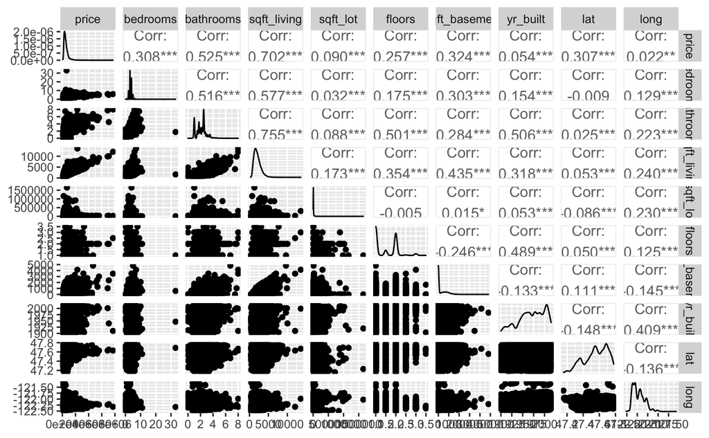

```r
ggpairs(kc_house_data_drop_num)
```

price ~ grade corr: 0.667 price ~ view corr: 0.397

[output not shown]

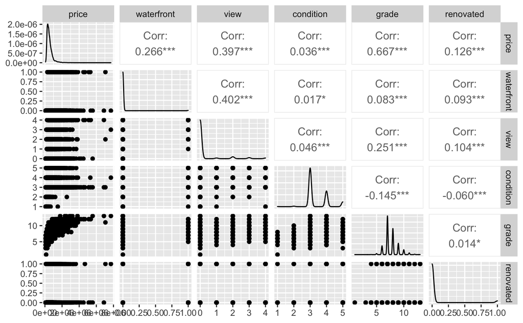

```r
ggpairs(kc_house_data_drop_grading)
```

## Modelling

### mod1a

first predictor

```r
summary(mod1a)
```

```
Call:
lm(formula = price ~ sqft_living, data = kc_house_data_drop_num)

Residuals:
     Min       1Q   Median       3Q      Max
-1476062  -147486   -24043   106182  4362067

Coefficients:
              Estimate Std. Error t value Pr(>|t|)
(Intercept) -43580.743   4402.690  -9.899   <2e-16 ***
sqft_living    280.624      1.936 144.920   <2e-16 ***
---
Signif. codes:  0 ‘***’ 0.001 ‘**’ 0.01 ‘*’ 0.05 ‘.’ 0.1 ‘ ’ 1

Residual standard error: 261500 on 21611 degrees of freedom
Multiple R-squared:  0.4929,    Adjusted R-squared:  0.4928
F-statistic: 2.1e+04 on 1 and 21611 DF,  p-value: < 2.2e-16
```

### mod1b

second predictor: `year_built`

From the numeric predictors, it looks like `bathrooms` has the strongest correlation, however, since it should be considered as living spaces, where included by `sqft_living`

r^2 value = 0.52 p-value: < 2.2e-16

[output not shown]

[output cut: 990 more lines]

```r
summary(mod1b)
```

```
Call:
lm(formula = price ~ sqft_living + yr_built, data = kc_house_data_drop_num)

Residuals:
     Min       1Q   Median       3Q      Max
-1684544  -137797   -20753   105703  4036827

Coefficients:
              Estimate Std. Error t value Pr(>|t|)
(Intercept)  4.546e+06  1.206e+05   37.69   <2e-16 ***
sqft_living  3.046e+02  1.977e+00  154.03   <2e-16 ***
yr_built    -2.354e+03  6.183e+01  -38.07   <2e-16 ***
---
Signif. codes:  0 ‘***’ 0.001 ‘**’ 0.01 ‘*’ 0.05 ‘.’ 0.1 ‘ ’ 1

Residual standard error: 253100 on 21610 degrees of freedom
Multiple R-squared:  0.5247,    Adjusted R-squared:  0.5247
F-statistic: 1.193e+04 on 2 and 21610 DF,  p-value: < 2.2e-16
```

### mod2a

r^2 value = 0.44, indicates that near 44% of the variability in the outcome data can be explained by the model p-value: < 2.2e-16

```r
summary(mod2a)
```

```
Call:
lm(formula = price ~ grade, data = kc_house_data_drop_grading)

Residuals:
    Min      1Q  Median      3Q     Max
-816988 -151958  -36158   97842 6046097

Coefficients:
            Estimate Std. Error t value Pr(>|t|)
(Intercept) -1056045      12256  -86.17   <2e-16 ***
grade         208458       1582  131.76   <2e-16 ***
---
Signif. codes:  0 ‘***’ 0.001 ‘**’ 0.01 ‘*’ 0.05 ‘.’ 0.1 ‘ ’ 1

Residual standard error: 273400 on 21611 degrees of freedom
Multiple R-squared:  0.4455,    Adjusted R-squared:  0.4454
F-statistic: 1.736e+04 on 1 and 21611 DF,  p-value: < 2.2e-16
```

### mod2b

second predictor: `view`

From the numeric predictors, it looks like `view` has the strongest correlation

r^2 value = 0.50 p-value: < 2.2e-16

[output not shown]

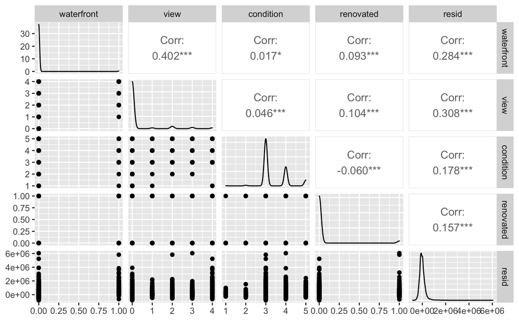

```r
ggpairs(kc_house_data_drop_grading_resid)
```

```r
summary(mod2b)
```

```
Call:
lm(formula = price ~ grade + view, data = kc_house_data_drop_grading)

Residuals:
     Min       1Q   Median       3Q      Max
-1045515  -139013   -28287    96713  5824201

Coefficients:
            Estimate Std. Error t value Pr(>|t|)
(Intercept)  -936282      11868  -78.89   <2e-16 ***
grade         189224       1550  122.12   <2e-16 ***
view          117389       2377   49.39   <2e-16 ***
---
Signif. codes:  0 ‘***’ 0.001 ‘**’ 0.01 ‘*’ 0.05 ‘.’ 0.1 ‘ ’ 1

Residual standard error: 259200 on 21610 degrees of freedom
Multiple R-squared:  0.5017,    Adjusted R-squared:  0.5017
F-statistic: 1.088e+04 on 2 and 21610 DF,  p-value: < 2.2e-16
```

### Check which model to use

Compare mod1b and mod2b:

```r
anova(mod1b, mod2b)
```

```
Analysis of Variance Table

Model 1: price ~ sqft_living + yr_built
Model 2: price ~ grade + view
  Res.Df        RSS Df   Sum of Sq F Pr(>F)
1  21610 1.3844e+15
2  21610 1.4515e+15  0 -6.7038e+13
```